# Practical Lab 3 - Vanilla CNN and Fine-Tune VGG16 - for Dogs and Cats Classification

### Most of the code used in this lab is taken from our course professor [Ran Feldesh](https://github.com/CSCN8010/CSCN8010).

# _____________________________________________

## Importing required libraries and frameworks

```python
import matplotlib.pyplot as plt
from tensorflow import keras
from tensorflow.keras import layers
import pathlib
from tensorflow.keras.utils import image_dataset_from_directory
```

# _____________________________________________

## Obtain the Data which is Dogs vs Cats dataset

##### *The next cell is for creating the folder "train_small" from the folder "train", but it has already been done before, If the **"train_small" folder is already available, Ignore** this cell and start from the following cell with changing the path*.

```python
original_dir = pathlib.Path("../Cat_dog_images/train")  # this extracts the train data
new_base_dir = pathlib.Path("../Cat_dog_images/train_small")

def make_subset(subset_name, start_index, end_index):
    for category in ("cat", "dog"):
        dir = new_base_dir / subset_name / category
        os.makedirs(dir)
        fnames = [f"{category}.{i}.jpg" for i in range(start_index, end_index)]
        for fname in fnames:
            shutil.copyfile(src=original_dir / fname,
                            dst=dir / fname)

make_subset("train", start_index=0, end_index=1000)
make_subset("validation", start_index=1000, end_index=1500)
make_subset("test", start_index=1500, end_index=2500)
```

[output not shown]

```python
data_folder = pathlib.Path('../CSCN8010-labs/train_small')
```

```python
train_dataset = image_dataset_from_directory(
    data_folder / "train",
    image_size=(180, 180),
    batch_size=32)
validation_dataset = image_dataset_from_directory(
    data_folder / "validation",
    image_size=(180, 180),
    batch_size=32)
test_dataset = image_dataset_from_directory(
    data_folder / "test",
    image_size=(180, 180),
    batch_size=32)
```

```
Found 2000 files belonging to 2 classes.
Found 1000 files belonging to 2 classes.
Found 2000 files belonging to 2 classes.
```

##### *The output of the above cell shows that there are:*

##### 2000 files in the train set for both the "Cats" and the "dogs"

##### 1000 files in the validation set for both the "Cats" and the "dogs"

##### 2000 files in the test set for both the "Cats" and the "dogs"

# _____________________________________________

## EDA

```python
class_counts = train_dataset.class_names
print(f"Classes: {class_counts}")
```

```
Classes: ['cat', 'dog']
```

##### *Those are the classes that we have*

```python
for image_batch, _ in train_dataset.take(1):
    print(f"Image batch shape: {image_batch.shape}")
```

```
Image batch shape: (32, 180, 180, 3)
```

##### *32: This is the batch size, meaning there are 32 images in the batch being processed at once.*

##### *180, 180: These are the dimensions of each image, indicating that each image is 180 pixels wide and 180 pixels tall.*

##### *3: This represents the number of color channels in each image. Since it's 3, the images are in RGB format (Red, Green, and Blue).*

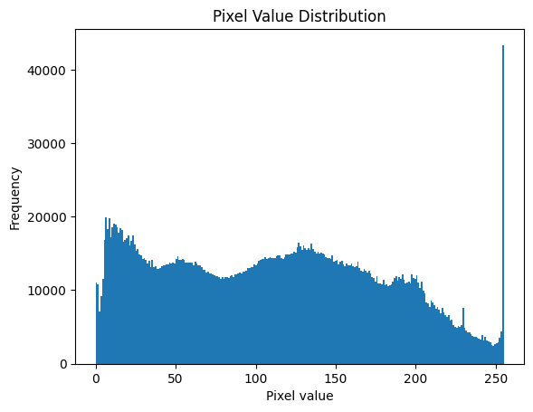

```python
for images, _ in train_dataset.take(1):
    plt.hist(images.numpy().ravel(), bins=256, range=(0, 255))
    plt.title("Pixel Value Distribution")
    plt.xlabel("Pixel value")
    plt.ylabel("Frequency")
```

##### *Histograms of pixel value distribution from 0 to 255, this is done to observe each pixels color as 0 symbolizes black and 255 symbolizes white.*

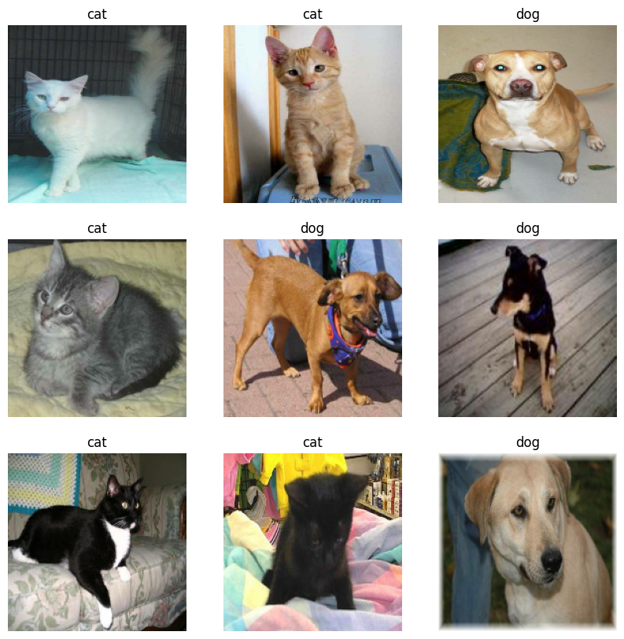

```python
import matplotlib.pyplot as plt

plt.figure(figsize=(10, 10))
for images, labels in train_dataset.take(1):
    for i in range(9):
        ax = plt.subplot(3, 3, i + 1)
        plt.imshow(images[i].numpy().astype("uint8"))
        plt.title(train_dataset.class_names[labels[i]])
        plt.axis("off")
```

##### *Randomized grid of images with labels to confirm the data quality.*

# _____________________________________________

## Definning the model

```python
inputs = keras.Input(shape=(180, 180, 3))
x = layers.Rescaling(1./255)(inputs)
x = layers.Conv2D(filters=32, kernel_size=3, activation="relu")(x)      # 32 neurones as there are 32 filters
x = layers.MaxPooling2D(pool_size=2)(x)
x = layers.Conv2D(filters=64, kernel_size=3, activation="relu")(x)
x = layers.MaxPooling2D(pool_size=2)(x)
x = layers.Conv2D(filters=128, kernel_size=3, activation="relu")(x)
x = layers.MaxPooling2D(pool_size=2)(x)
x = layers.Conv2D(filters=256, kernel_size=3, activation="relu")(x)
x = layers.MaxPooling2D(pool_size=2)(x)
x = layers.Conv2D(filters=256, kernel_size=3, activation="relu")(x)
x = layers.Flatten()(x)
outputs = layers.Dense(1, activation="sigmoid")(x)
model = keras.Model(inputs=inputs, outputs=outputs)
```

```python
model.summary()
```

```
Model: "model_5"
_________________________________________________________________
 Layer (type)                Output Shape              Param #
=================================================================
 input_8 (InputLayer)        [(None, 180, 180, 3)]     0

 rescaling_3 (Rescaling)     (None, 180, 180, 3)       0

 conv2d_15 (Conv2D)          (None, 178, 178, 32)      896

 max_pooling2d_12 (MaxPoolin  (None, 89, 89, 32)       0
 g2D)

 conv2d_16 (Conv2D)          (None, 87, 87, 64)        18496

 max_pooling2d_13 (MaxPoolin  (None, 43, 43, 64)       0
 g2D)

 conv2d_17 (Conv2D)          (None, 41, 41, 128)       73856

 max_pooling2d_14 (MaxPoolin  (None, 20, 20, 128)      0
 g2D)

 conv2d_18 (Conv2D)          (None, 18, 18, 256)       295168

 max_pooling2d_15 (MaxPoolin  (None, 9, 9, 256)        0
 g2D)

 conv2d_19 (Conv2D)          (None, 7, 7, 256)         590080

 flatten_5 (Flatten)         (None, 12544)             0

 dense_7 (Dense)             (None, 1)                 12545

=================================================================
Total params: 991,041
Trainable params: 991,041
Non-trainable params: 0
_________________________________________________________________
```

```python
model.compile(loss="binary_crossentropy",
              optimizer="rmsprop",
              metrics=["accuracy"])
```

```python
callbacks = [
    keras.callbacks.ModelCheckpoint(
        filepath="./models/convnet_from_scratch.keras",
        save_best_only=True,
        monitor="val_loss")
]
history = model.fit(
    train_dataset,
    epochs=35,
    validation_data=validation_dataset,
    callbacks=callbacks)
```

##### the CNN is stored in **convnet_from_scratch.keras**

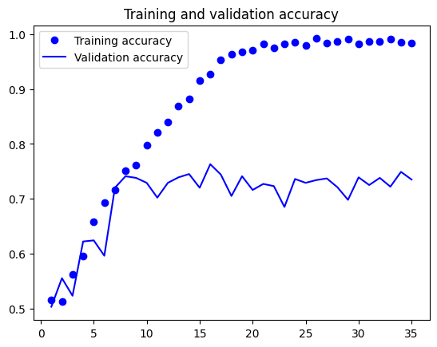

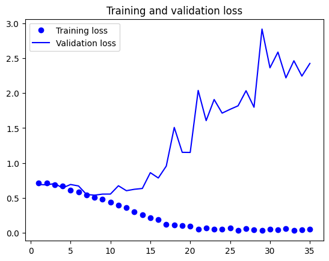

```python
import matplotlib.pyplot as plt

accuracy = history.history["accuracy"]
val_accuracy = history.history["val_accuracy"]
loss = history.history["loss"]
val_loss = history.history["val_loss"]
epochs = range(1, len(accuracy) + 1)

# accuracy plot
plt.plot(epochs, accuracy, "bo", label="Training accuracy")
plt.plot(epochs, val_accuracy, "b", label="Validation accuracy")
plt.title("Training and validation accuracy")
plt.legend()
plt.xticks(range(0, len(epochs) + 1, 5))
plt.figure()

# loss plot
plt.plot(epochs, loss, "bo", label="Training loss")
plt.plot(epochs, val_loss, "b", label="Validation loss")
plt.title("Training and validation loss")
plt.legend()
plt.xticks(range(0, len(epochs) + 1, 5))
plt.show()
```

```python
test_model = keras.models.load_model("./models/convnet_from_scratch.keras")
test_loss, test_acc = test_model.evaluate(test_dataset)
print(f"Test accuracy: {test_acc:.3f}")
```

```
Test accuracy: 0.733
```

# _____________________________________________

## Using the vgg16 base and training our own top

```python
conv_base = keras.applications.vgg16.VGG16( #Download an existing network, everythong exept the top
    weights="imagenet",
    include_top=False,
    input_shape=(180, 180, 3))
```

```python
conv_base.summary()
```

```
Model: "vgg16"
_________________________________________________________________
 Layer (type)                Output Shape              Param #
=================================================================
 input_9 (InputLayer)        [(None, 180, 180, 3)]     0

 block1_conv1 (Conv2D)       (None, 180, 180, 64)      1792

 block1_conv2 (Conv2D)       (None, 180, 180, 64)      36928

 block1_pool (MaxPooling2D)  (None, 90, 90, 64)        0

 block2_conv1 (Conv2D)       (None, 90, 90, 128)       73856

 block2_conv2 (Conv2D)       (None, 90, 90, 128)       147584

 block2_pool (MaxPooling2D)  (None, 45, 45, 128)       0

 block3_conv1 (Conv2D)       (None, 45, 45, 256)       295168

 block3_conv2 (Conv2D)       (None, 45, 45, 256)       590080

 block3_conv3 (Conv2D)       (None, 45, 45, 256)       590080

 block3_pool (MaxPooling2D)  (None, 22, 22, 256)       0

 block4_conv1 (Conv2D)       (None, 22, 22, 512)       1180160

 block4_conv2 (Conv2D)       (None, 22, 22, 512)       2359808

 block4_conv3 (Conv2D)       (None, 22, 22, 512)       2359808

 block4_pool (MaxPooling2D)  (None, 11, 11, 512)       0

 block5_conv1 (Conv2D)       (None, 11, 11, 512)       2359808

 block5_conv2 (Conv2D)       (None, 11, 11, 512)       2359808

 block5_conv3 (Conv2D)       (None, 11, 11, 512)       2359808

 block5_pool (MaxPooling2D)  (None, 5, 5, 512)         0

=================================================================
Total params: 14,714,688
Trainable params: 14,714,688
Non-trainable params: 0
_________________________________________________________________
```

```python
data_folder = pathlib.Path('../CSCN8010-labs/train_small')

train_dataset = image_dataset_from_directory(
    data_folder / "train",
    image_size=(180, 180),
    batch_size=32)
validation_dataset = image_dataset_from_directory(
    data_folder / "validation",
    image_size=(180, 180),
    batch_size=32)
test_dataset = image_dataset_from_directory(
    data_folder / "test",
    image_size=(180, 180),
    batch_size=32)
```

```
Found 2000 files belonging to 2 classes.
Found 1000 files belonging to 2 classes.
Found 2000 files belonging to 2 classes.
```

```python
import numpy as np

def get_features_and_labels(dataset):
    all_features = []
    all_labels = []
    for images, labels in dataset:
        preprocessed_images = keras.applications.vgg16.preprocess_input(images)
        features = conv_base.predict(preprocessed_images)
        all_features.append(features)
        all_labels.append(labels)
    return np.concatenate(all_features), np.concatenate(all_labels)

train_features, train_labels =  get_features_and_labels(train_dataset)
val_features, val_labels =  get_features_and_labels(validation_dataset)
test_features, test_labels =  get_features_and_labels(test_dataset)
```

```python
train_features.shape
```

```
(2000, 5, 5, 512)
```

## We train our own top

```python
inputs = keras.Input(shape=(5, 5, 512))  #  Defining and training the top, because the bottom layer is the same as it was trained on similar real world data so the feature detectors will be the same
x = layers.Flatten()(inputs)
x = layers.Dense(256)(x)
x = layers.Dropout(0.5)(x)  # it says that the output doesn't rely on the best neurones, it sets their output to 0 in 50% of times or number of epoches, if there are 4 epoches , the output will not rely on the best neurones for 2 epoches so the other nuerones will always try to be better.
outputs = layers.Dense(1, activation="sigmoid")(x)
model = keras.Model(inputs, outputs)
```

```python
model.summary()
```

```
Model: "model_6"
_________________________________________________________________
 Layer (type)                Output Shape              Param #
=================================================================
 input_10 (InputLayer)       [(None, 5, 5, 512)]       0

 flatten_6 (Flatten)         (None, 12800)             0

 dense_8 (Dense)             (None, 256)               3277056

 dropout_2 (Dropout)         (None, 256)               0

 dense_9 (Dense)             (None, 1)                 257

=================================================================
Total params: 3,277,313
Trainable params: 3,277,313
Non-trainable params: 0
_________________________________________________________________
```

```python
model.compile(loss="binary_crossentropy",
              optimizer="rmsprop",
              metrics=["accuracy"])

callbacks = [
    keras.callbacks.ModelCheckpoint(
      filepath="./models/feature_extraction.keras",
      save_best_only=True,
      monitor="val_loss")
]
history = model.fit(
    train_features, train_labels,
    epochs=35,
    validation_data=(val_features, val_labels),
    callbacks=callbacks)
```

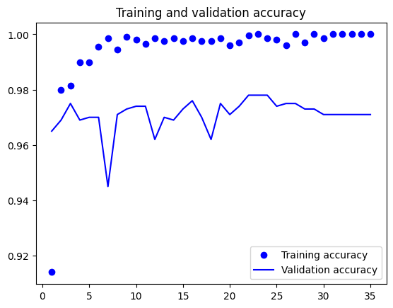

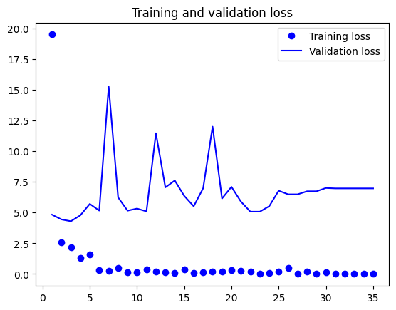

```python
import matplotlib.pyplot as plt
acc = history.history["accuracy"]
val_acc = history.history["val_accuracy"]
loss = history.history["loss"]
val_loss = history.history["val_loss"]
epochs = range(1, len(acc) + 1)
plt.plot(epochs, acc, "bo", label="Training accuracy")
plt.plot(epochs, val_acc, "b", label="Validation accuracy")
plt.title("Training and validation accuracy")
plt.legend()
plt.figure()
plt.plot(epochs, loss, "bo", label="Training loss")
plt.plot(epochs, val_loss, "b", label="Validation loss")
plt.title("Training and validation loss")
plt.legend()
plt.show()
```

```python
test_model = keras.models.load_model(
    "./models/feature_extraction.keras")
test_loss, test_acc = test_model.evaluate(x=test_features, y=test_labels)
print(f"Test accuracy: {test_acc:.3f}")
```

```
Test accuracy: 0.969
```

# _____________________________________________

```python
conv_base  = keras.applications.vgg16.VGG16(
    weights="imagenet",
    include_top=False)
```

```python
conv_base.summary()
```

```
Model: "vgg16"
_________________________________________________________________
 Layer (type)                Output Shape              Param #
=================================================================
 input_11 (InputLayer)       [(None, None, None, 3)]   0

 block1_conv1 (Conv2D)       (None, None, None, 64)    1792

 block1_conv2 (Conv2D)       (None, None, None, 64)    36928

 block1_pool (MaxPooling2D)  (None, None, None, 64)    0

 block2_conv1 (Conv2D)       (None, None, None, 128)   73856

 block2_conv2 (Conv2D)       (None, None, None, 128)   147584

 block2_pool (MaxPooling2D)  (None, None, None, 128)   0

 block3_conv1 (Conv2D)       (None, None, None, 256)   295168

 block3_conv2 (Conv2D)       (None, None, None, 256)   590080

 block3_conv3 (Conv2D)       (None, None, None, 256)   590080

 block3_pool (MaxPooling2D)  (None, None, None, 256)   0

 block4_conv1 (Conv2D)       (None, None, None, 512)   1180160

 block4_conv2 (Conv2D)       (None, None, None, 512)   2359808

 block4_conv3 (Conv2D)       (None, None, None, 512)   2359808

 block4_pool (MaxPooling2D)  (None, None, None, 512)   0

 block5_conv1 (Conv2D)       (None, None, None, 512)   2359808

 block5_conv2 (Conv2D)       (None, None, None, 512)   2359808

 block5_conv3 (Conv2D)       (None, None, None, 512)   2359808

 block5_pool (MaxPooling2D)  (None, None, None, 512)   0

=================================================================
Total params: 14,714,688
Trainable params: 14,714,688
Non-trainable params: 0
_________________________________________________________________
```

```python
conv_base.trainable = False  # freeze the weighs so the image will be trained with the same weights of the base
conv_base.summary()
```

```
Model: "vgg16"
_________________________________________________________________
 Layer (type)                Output Shape              Param #
=================================================================
 input_11 (InputLayer)       [(None, None, None, 3)]   0

 block1_conv1 (Conv2D)       (None, None, None, 64)    1792

 block1_conv2 (Conv2D)       (None, None, None, 64)    36928

 block1_pool (MaxPooling2D)  (None, None, None, 64)    0

 block2_conv1 (Conv2D)       (None, None, None, 128)   73856

 block2_conv2 (Conv2D)       (None, None, None, 128)   147584

 block2_pool (MaxPooling2D)  (None, None, None, 128)   0

 block3_conv1 (Conv2D)       (None, None, None, 256)   295168

 block3_conv2 (Conv2D)       (None, None, None, 256)   590080

 block3_conv3 (Conv2D)       (None, None, None, 256)   590080

 block3_pool (MaxPooling2D)  (None, None, None, 256)   0

 block4_conv1 (Conv2D)       (None, None, None, 512)   1180160

 block4_conv2 (Conv2D)       (None, None, None, 512)   2359808

 block4_conv3 (Conv2D)       (None, None, None, 512)   2359808

 block4_pool (MaxPooling2D)  (None, None, None, 512)   0

 block5_conv1 (Conv2D)       (None, None, None, 512)   2359808

 block5_conv2 (Conv2D)       (None, None, None, 512)   2359808

 block5_conv3 (Conv2D)       (None, None, None, 512)   2359808

 block5_pool (MaxPooling2D)  (None, None, None, 512)   0

=================================================================
Total params: 14,714,688
Trainable params: 0
Non-trainable params: 14,714,688
_________________________________________________________________
```

```python
data_augmentation = keras.Sequential(
    [
        layers.RandomFlip("horizontal"), #horizontal flip and not vertical
        layers.RandomRotation(0.1), #Rotation of 0.1 radians not degrees
        layers.RandomZoom(0.2),
    ]
)

inputs = keras.Input(shape=(180, 180, 3))
x = data_augmentation(inputs)
x = keras.applications.vgg16.preprocess_input(x) ###ٌ RGB, BGR preprocess
x = conv_base(x)
x = layers.Flatten()(x)
x = layers.Dense(256)(x)
x = layers.Dropout(0.3)(x)  # I set the dropout to 0.3
outputs = layers.Dense(1, activation="sigmoid")(x)
model = keras.Model(inputs, outputs)
```

```python
model.summary() #to make sure that no weight changed look at the result where "Total params: 17,992,001 and Trainable params: 3,277,313". this proves that the weights of the base are not trained and are freezed
```

```
Model: "model_7"
_________________________________________________________________
 Layer (type)                Output Shape              Param #
=================================================================
 input_12 (InputLayer)       [(None, 180, 180, 3)]     0

 sequential_1 (Sequential)   (None, 180, 180, 3)       0

 tf.__operators__.getitem_1   (None, 180, 180, 3)      0
 (SlicingOpLambda)

 tf.nn.bias_add_1 (TFOpLambd  (None, 180, 180, 3)      0
 a)

 vgg16 (Functional)          (None, None, None, 512)   14714688

 flatten_7 (Flatten)         (None, 12800)             0

 dense_10 (Dense)            (None, 256)               3277056

 dropout_3 (Dropout)         (None, 256)               0

 dense_11 (Dense)            (None, 1)                 257

=================================================================
Total params: 17,992,001
Trainable params: 3,277,313
Non-trainable params: 14,714,688
_________________________________________________________________
```

```python
model.compile(loss="binary_crossentropy",
              optimizer="rmsprop",
              metrics=["accuracy"])

callbacks = [
    keras.callbacks.ModelCheckpoint(
        filepath="./models/feature_extraction_with_data_augmentation.keras",
        save_best_only=True,
        monitor="val_loss")
]
history = model.fit(
    train_dataset,
    epochs=35,
    validation_data=validation_dataset,
    callbacks=callbacks) #Epoch 25 reached at min 47 min :41 sec
#Epoch 25 reached at min 49 min :30 sec
#Epoch 50 reached at min 97 min :06 sec
```

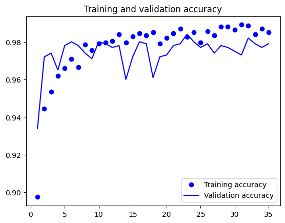

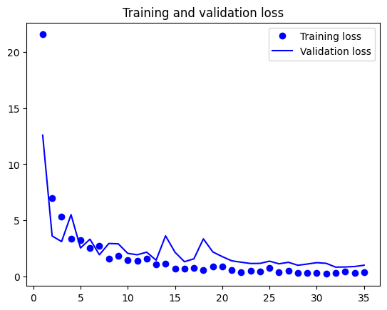

```python
acc = history.history["accuracy"]
val_acc = history.history["val_accuracy"]
loss = history.history["loss"]
val_loss = history.history["val_loss"]
epochs = range(1, len(acc) + 1)
plt.plot(epochs, acc, "bo", label="Training accuracy")
plt.plot(epochs, val_acc, "b", label="Validation accuracy")
plt.title("Training and validation accuracy")
plt.legend()
plt.figure()
plt.plot(epochs, loss, "bo", label="Training loss")
plt.plot(epochs, val_loss, "b", label="Validation loss")
plt.title("Training and validation loss")
plt.legend()
plt.show()
```

```python
test_model = keras.models.load_model(
    "./models/feature_extraction_with_data_augmentation.keras")
test_loss, test_acc = test_model.evaluate(test_dataset)
print(f"Test accuracy: {test_acc:.3f}")
```

```
Test accuracy: 0.972
```

# ______________________________________________________

## Training the top 3 layers of the base as they may contain some specific features that if modified with different weights and bias, they might give a higher accuracy

```python
conv_base.summary()
```

```
Model: "vgg16"
_________________________________________________________________
 Layer (type)                Output Shape              Param #
=================================================================
 input_11 (InputLayer)       [(None, None, None, 3)]   0

 block1_conv1 (Conv2D)       (None, None, None, 64)    1792

 block1_conv2 (Conv2D)       (None, None, None, 64)    36928

 block1_pool (MaxPooling2D)  (None, None, None, 64)    0

 block2_conv1 (Conv2D)       (None, None, None, 128)   73856

 block2_conv2 (Conv2D)       (None, None, None, 128)   147584

 block2_pool (MaxPooling2D)  (None, None, None, 128)   0

 block3_conv1 (Conv2D)       (None, None, None, 256)   295168

 block3_conv2 (Conv2D)       (None, None, None, 256)   590080

 block3_conv3 (Conv2D)       (None, None, None, 256)   590080

 block3_pool (MaxPooling2D)  (None, None, None, 256)   0

 block4_conv1 (Conv2D)       (None, None, None, 512)   1180160

 block4_conv2 (Conv2D)       (None, None, None, 512)   2359808

 block4_conv3 (Conv2D)       (None, None, None, 512)   2359808

 block4_pool (MaxPooling2D)  (None, None, None, 512)   0

 block5_conv1 (Conv2D)       (None, None, None, 512)   2359808

 block5_conv2 (Conv2D)       (None, None, None, 512)   2359808

 block5_conv3 (Conv2D)       (None, None, None, 512)   2359808

 block5_pool (MaxPooling2D)  (None, None, None, 512)   0

=================================================================
Total params: 14,714,688
Trainable params: 0
Non-trainable params: 14,714,688
_________________________________________________________________
```

```python
conv_base.trainable = True
for layer in conv_base.layers[:-3]:  # we don't freeze the last 3 layers to check if we can modify the weights to give us a better accuracy at the end
    layer.trainable = False
```

```python
model.summary()
```

```
Model: "model_7"
_________________________________________________________________
 Layer (type)                Output Shape              Param #
=================================================================
 input_12 (InputLayer)       [(None, 180, 180, 3)]     0

 sequential_1 (Sequential)   (None, 180, 180, 3)       0

 tf.__operators__.getitem_1   (None, 180, 180, 3)      0
 (SlicingOpLambda)

 tf.nn.bias_add_1 (TFOpLambd  (None, 180, 180, 3)      0
 a)

 vgg16 (Functional)          (None, None, None, 512)   14714688

 flatten_7 (Flatten)         (None, 12800)             0

 dense_10 (Dense)            (None, 256)               3277056

 dropout_3 (Dropout)         (None, 256)               0

 dense_11 (Dense)            (None, 1)                 257

=================================================================
Total params: 17,992,001
Trainable params: 7,996,929
Non-trainable params: 9,995,072
_________________________________________________________________
```

```python
model.compile(loss="binary_crossentropy",
              optimizer=keras.optimizers.RMSprop(learning_rate=1e-5),
              metrics=["accuracy"])

callbacks = [
    keras.callbacks.ModelCheckpoint(
        filepath="./models/fine_tuning.keras",
        save_best_only=True,
        monitor="val_loss")
]
history = model.fit(
    train_dataset,
    epochs=35,
    validation_data=validation_dataset,
    callbacks=callbacks)
```

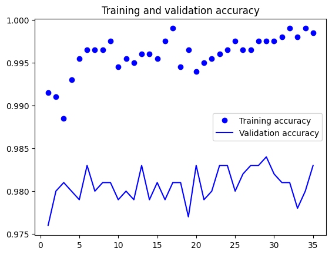

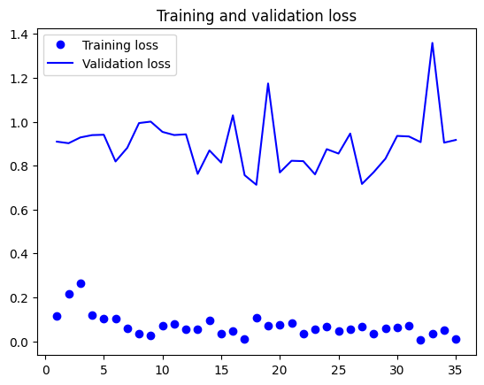

```python
acc = history.history["accuracy"]
val_acc = history.history["val_accuracy"]
loss = history.history["loss"]
val_loss = history.history["val_loss"]
epochs = range(1, len(acc) + 1)
plt.plot(epochs, acc, "bo", label="Training accuracy")
plt.plot(epochs, val_acc, "b", label="Validation accuracy")
plt.title("Training and validation accuracy")
plt.legend()
plt.figure()
plt.plot(epochs, loss, "bo", label="Training loss")
plt.plot(epochs, val_loss, "b", label="Validation loss")
plt.title("Training and validation loss")
plt.legend()
plt.show()
```

```python
model = keras.models.load_model("./models/fine_tuning.keras")
test_loss, test_acc = model.evaluate(test_dataset)
print(f"Test accuracy: {test_acc:.3f}")
```

```
Test accuracy: 0.977
```

```python
test_loss, test_accuracy = model.evaluate(test_dataset)
print(f"Test Accuracy: {test_accuracy:.2f}")
```

```
Test Accuracy: 0.98
```

# ______________________________________________________________________

## Performance Evaluation

```python
from tensorflow.keras.models import load_model

models = {
    "convnet_from_scratch": load_model("./models/convnet_from_scratch.keras"),
    "feature_extraction": load_model("./models/feature_extraction.keras"),
    "feature_extraction_aug": load_model("./models/feature_extraction_with_data_augmentation.keras"),
    "fine_tuning": load_model("./models/fine_tuning.keras")
}
```

```python
results = {}

for name, model in models.items():
    try:
        if name == "feature_extraction":  # Models using pre-extracted features
            test_loss, test_acc = model.evaluate(test_features, test_labels)
        else:  # Models using raw images
            test_loss, test_acc = model.evaluate(test_dataset)
        results[name] = {"accuracy": test_acc}
        print(f"{name} - Accuracy: {test_acc:.3f}")
    except ValueError as e:
        print(f"Error with model {name}: {e}")
```

```
convnet_from_scratch - Accuracy: 0.733
feature_extraction - Accuracy: 0.969
feature_extraction_aug - Accuracy: 0.972
fine_tuning - Accuracy: 0.977
```

```python
from sklearn.metrics import confusion_matrix

for name, model in models.items():
    try:
        if name == "feature_extraction":
            predictions = (model.predict(test_features) > 0.5).astype("int32")
            true_labels = test_labels
        else:
            predictions = (model.predict(test_dataset) > 0.5).astype("int32")
            true_labels = np.concatenate([y for _, y in test_dataset], axis=0)

        cm = confusion_matrix(true_labels, predictions)
        results[name]["confusion_matrix"] = cm
        print(f"Confusion Matrix for {name}:\n{cm}")
    except ValueError as e:
        print(f"Error with model {name}: {e}")
```

```
Confusion Matrix for convnet_from_scratch:
[[409 591]
 [454 546]]
Confusion Matrix for feature_extraction:
[[980  20]
 [ 43 957]]
Confusion Matrix for feature_extraction_aug:
[[513 487]
 [509 491]]
Confusion Matrix for fine_tuning:
[[509 491]
 [507 493]]
```

```python
from sklearn.metrics import classification_report

for name, model in models.items():
    try:
        if name == "feature_extraction":
            predictions = (model.predict(test_features) > 0.5).astype("int32")
            true_labels = test_labels
        else:
            predictions = (model.predict(test_dataset) > 0.5).astype("int32")
            true_labels = np.concatenate([y for _, y in test_dataset], axis=0)

        report = classification_report(true_labels, predictions, output_dict=True)
        results[name]["precision"] = report["1"]["precision"]
        results[name]["recall"] = report["1"]["recall"]
        results[name]["f1_score"] = report["1"]["f1-score"]

        print(f"Classification Report for {name}:\n{classification_report(true_labels, predictions)}")
    except ValueError as e:
        print(f"Error with model {name}: {e}")
```

```
Classification Report for convnet_from_scratch:
              precision    recall  f1-score   support

           0       0.50      0.43      0.46      1000
           1       0.50      0.57      0.53      1000

    accuracy                           0.50      2000
   macro avg       0.50      0.50      0.50      2000
weighted avg       0.50      0.50      0.50      2000

Classification Report for feature_extraction:
              precision    recall  f1-score   support

           0       0.96      0.98      0.97      1000
           1       0.98      0.96      0.97      1000

    accuracy                           0.97      2000
   macro avg       0.97      0.97      0.97      2000
weighted avg       0.97      0.97      0.97      2000

Classification Report for feature_extraction_aug:
              precision    recall  f1-score   support

           0       0.49      0.50      0.49      1000
           1       0.49      0.47      0.48      1000

    accuracy                           0.49      2000
   macro avg       0.49      0.49      0.49      2000
weighted avg       0.49      0.49      0.49      2000

Classification Report for fine_tuning:
              precision    recall  f1-score   support

           0       0.50      0.50      0.50      1000
           1       0.50      0.49      0.49      1000

    accuracy                           0.50      2000
   macro avg       0.50      0.50      0.50      2000
weighted avg       0.50      0.50      0.50      2000
```

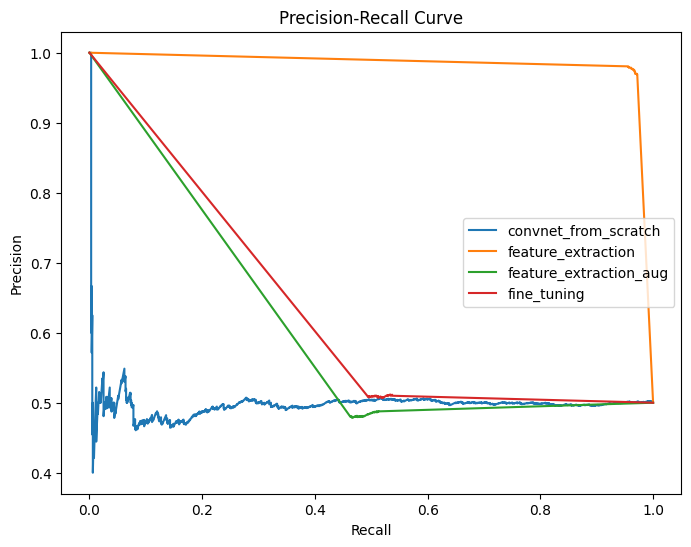

```python
from sklearn.metrics import precision_recall_curve
import matplotlib.pyplot as plt

plt.figure(figsize=(8, 6))
for name, model in models.items():
    try:
        if name == "feature_extraction":
            probabilities = model.predict(test_features).flatten()
            true_labels = test_labels
        else:
            probabilities = model.predict(test_dataset).flatten()
            true_labels = np.concatenate([y for _, y in test_dataset], axis=0)

        precision, recall, _ = precision_recall_curve(true_labels, probabilities)
        plt.plot(recall, precision, label=name)
    except ValueError as e:
        print(f"Error with model {name}: {e}")

plt.xlabel("Recall")
plt.ylabel("Precision")
plt.title("Precision-Recall Curve")
plt.legend()
plt.show()
```